# Stat 579 - Life Expectancy

8/30/2019

# Life Expectancy in Mexico, Canada and the US

## Step-by-step plan of work

1. Read the data
2. Focus on values of Canada
3. Visualize the values for Canada
4. See whether we can find the problem
5. … then we’ll see …

## Reading the data

```r
url5060 <- "https://raw.githubusercontent.com/Stat579-at-ISU/stat579-at-isu.github.io/master/homework/data/gapminder-5060.csv" # nasty looking, but doesn't make any assumptions about data on your machine
life5060 <- read.csv(url5060)
head(life5060)
```

```
##       country continent year lifeExp      pop gdpPercap
## 1 Afghanistan      Asia 1952  28.801  8425333  779.4453
## 2 Afghanistan      Asia 1957  30.332  9240934  820.8530
## 3 Afghanistan      Asia 1962  31.997 10267083  853.1007
## 4 Afghanistan      Asia 1967  34.020 11537966  836.1971
## 5     Albania    Europe 1952  55.230  1282697 1601.0561
## 6     Albania    Europe 1957  59.280  1476505 1942.2842
```

## Focus on the values for Canada

```r
canada <- life5060 %>% filter(country == "Canada")
head(canada)
```

```
##   country continent year   lifeExp      pop gdpPercap
## 1  Canada  Americas 1952     68.75 14785584  11367.16
## 2  Canada  Americas 1957 999999.00 17010154  12489.95
## 3  Canada  Americas 1962     71.30 18985849  13462.49
## 4  Canada  Americas 1967     72.13 20819767  16076.59
```

## Visualize

Draw a line for the life expectancy in Canada:

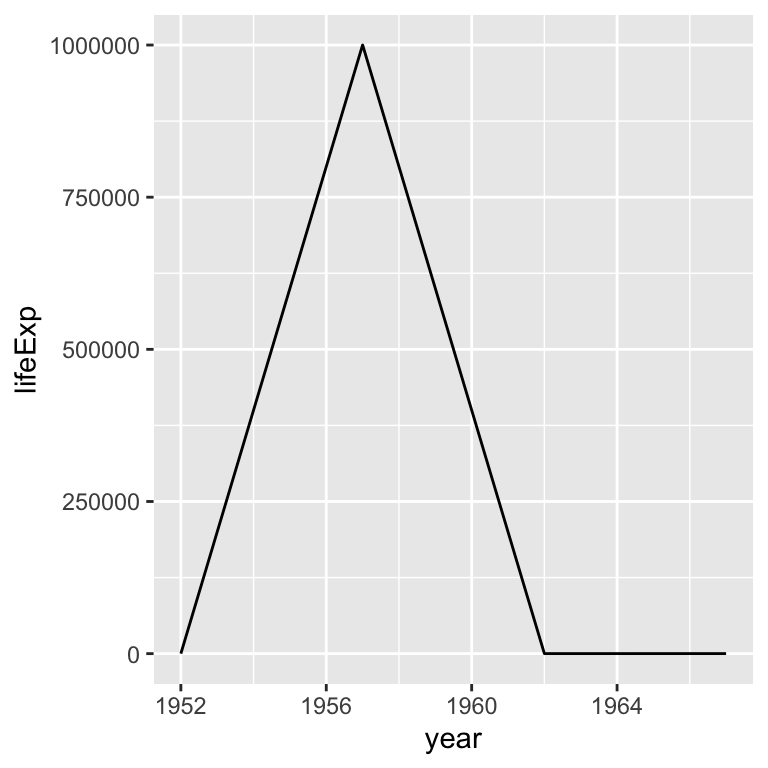

```r
canada %>%
  ggplot(aes(x = year, y = lifeExp)) +
  geom_line()
```

Clearly there is something wrong with the value in 1957.

## Find the problematic value and fix it

```r
canada %>% filter(year == 1957)
```

```
##   country continent year lifeExp      pop gdpPercap
## 1  Canada  Americas 1957  999999 17010154  12489.95
```

```r
canada_fixed <- canada %>% mutate(
  lifeExp = replace(lifeExp, year==1957, 69.96)
)
```

## visualize the fixed data

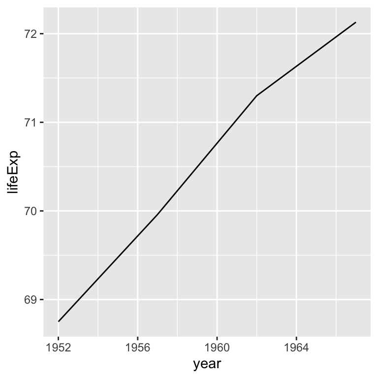

```r
canada_fixed %>% ggplot(aes(x = year, y = lifeExp)) +
  geom_line()
```

## … on to the stretch goal …

Add lines for Mexico and the US

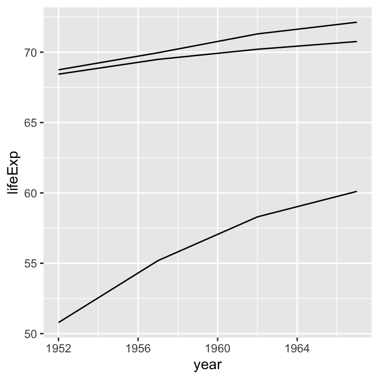

```r
canada_fixed %>%
  ggplot(aes(x = year, y = lifeExp, group=country)) + geom_line() +
  geom_line(data = life5060 %>%
              filter(country %in% c("United States", "Mexico")))
```

## … on to the stretch goal …

Add lines for Mexico and the US, color lines by country and add a legend

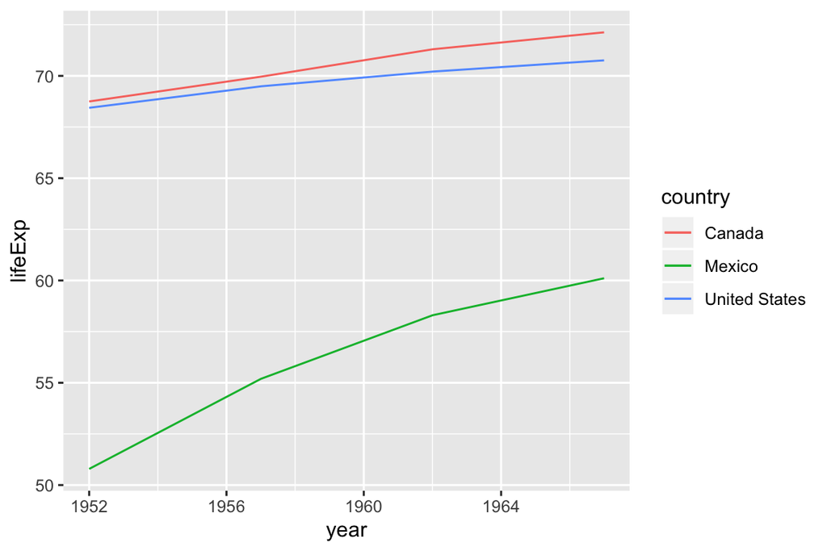

```r
canada_fixed %>%
  ggplot(aes(x = year, y = lifeExp, colour=country)) + geom_line() +
  geom_line(data = life5060 %>%
              filter(country %in% c("United States", "Mexico")))
```

## Adding the second dataset

Here we want to download and store the data for life expectancy from 70 to 80.

```r
url7080 <- "https://raw.githubusercontent.com/Stat579-at-ISU/stat579-at-isu.github.io/master/homework/data/gap7080.csv"
life7080 <- read.csv(url7080)

head(life7080)
```

```
##       country continent year lifeExp      pop gdpPercap
## 1 Afghanistan      Asia 1972  36.088 13079460  739.9811
## 2 Afghanistan      Asia 1977  38.438 14880372  786.1134
## 3 Afghanistan      Asia 1982  39.854 12881816  978.0114
## 4 Afghanistan      Asia 1987  40.822 13867957  852.3959
## 5     Albania    Europe 1972  67.690  2263554 3313.4222
## 6     Albania    Europe 1977  68.930  2509048 3533.0039
```

## Merging

Here, we want to combine all datasets to one unified dataset.

```r
life5080 = bind_rows(canada_fixed, life7080,
                      life5060 %>% filter(country != 'Canada'))
```

## Visualization

Now, we can visualize the data to see the trend about the life expectancy of *US*, *Mexico* and *Canada*.

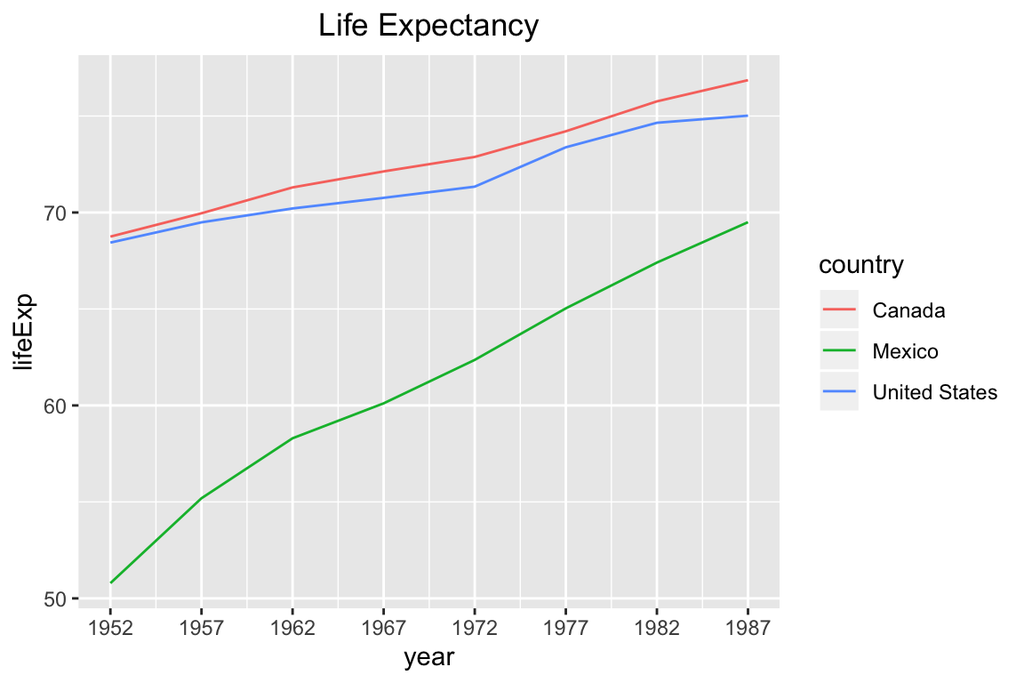

```r
life5080 %>%
  filter(country %in% c("Canada", "United States", "Mexico")) %>%
  ggplot(aes(x=year, y=lifeExp))+
  geom_line(aes(color=country))+
  ggtitle('Life Expectancy')+
  scale_x_continuous(breaks = seq(1952,1987,5))+
  theme(plot.title = element_text(hjust = 0.5))
```

## Comparison

We can compare the results to see how the trend has been changed from 50-60 to 70-80.

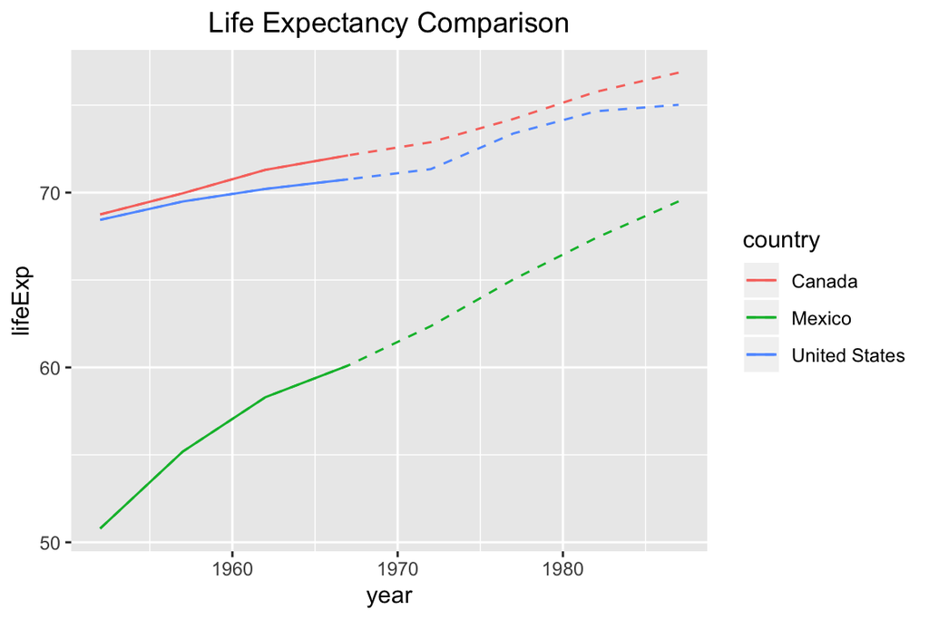

```r
canada_fixed %>%
  ggplot(aes(x = year, y = lifeExp, colour=country)) + geom_line() +
  geom_line(data = life5060 %>%
              filter(country %in% c("United States", "Mexico")))+
  geom_line(data=life5080 %>%
              filter(country %in% c("Canada", "United States", "Mexico")),
            aes(color=country), linetype='dashed')+
  ggtitle('Life Expectancy Comparison')+
  theme(plot.title = element_text(hjust = 0.5))
```

## Conclusions

1. As we can see the Canada has the highest life expectancy, while Mexico has the lowest.
2. The rate of increase for Mexico is bigger than that of US, or Canada. We can clearly see that the differnce is very large at the beginning, but it decreases as time goes on.